# Project 1

Author

Zane Mohammad

## Data Organization

### Get Data

```r
library(dplyr)
library(ggplot2)
library(tidyr)
library(knitr)
library(stringr)
classics <- read.csv("data/classics.csv")
```

### Trim Excess Data

(most of these texts are translated into English, so the `bibliography.languages` doesn’t mean much)  
(the subjects, as categorized here (`bibliography.subjects`), are difficult to parse through, we are better off using the `bibliography.congress.classifications` to do so)  
(There are only 2 `bibliography.type`(s) that are not “text”)

(`metadata.rank` can be derived from `metadata.downloads`)

```r
classics <- classics |>
  select(-metadata.url, -bibliography.languages, -bibliography.subjects, -metadata.id, -metadata.formats.total, -metadata.formats.types, -bibliography.type, -metadata.rank)
```

### Rename Elements

```r
classics <- classics |>
  rename(
    LoC_classifications = `bibliography.congress.classifications`,
    title = `bibliography.title`,
    stats.downloads = `metadata.downloads`,
    author.birthdate = `bibliography.author.birth`,
    author.deathdate = `bibliography.author.death`,
    author.name = `bibliography.author.name`,
    pub.date = `bibliography.publication.day`,
    pub.date_full = `bibliography.publication.full`,
    pub.month = `bibliography.publication.month`,
    pub.month_name = `bibliography.publication.month.name`,
    pub.year = `bibliography.publication.year`,
    difficulty.ari = `metrics.difficulty.automated.readability.index`,
    difficulty.coleman = `metrics.difficulty.coleman.liau.index`,
    difficulty.dale = `metrics.difficulty.dale.chall.readability.score`,
    difficulty.vocabulary = `metrics.difficulty.difficult.words`,
    difficulty.flesch.grade = `metrics.difficulty.flesch.kincaid.grade`,
    difficulty.flesch.ease = `metrics.difficulty.flesch.reading.ease`,
    difficulty.gunning = `metrics.difficulty.gunning.fog`,
    difficulty.linsear = `metrics.difficulty.linsear.write.formula`,
    difficulty.smog = `metrics.difficulty.smog.index`,
    stats.polarity = `metrics.sentiments.polarity`,
    stats.subjectivity = `metrics.sentiments.subjectivity`,
    stats.avg_letter_per_word = `metrics.statistics.average.letter.per.word`,
    stats.avg_sentence_length = `metrics.statistics.average.sentence.length`,
    stats.sentences_over_words = `metrics.statistics.average.sentence.per.word`,
    stats.characters = `metrics.statistics.characters`,
    stats.polysyllables = `metrics.statistics.polysyllables`,
    stats.sentences = `metrics.statistics.sentences`,
    stats.syllables = `metrics.statistics.syllables`,
    stats.words = `metrics.statistics.words`
  )
glimpse(classics)
```

[output not shown]

### Make Data Dictionary

```r
create_data_dictionary <- function(data) {
  data_dict <- data.frame(
    Column_Name = names(data),
    Data_Type = sapply(data, class),
    Description = "",
    Example_Values = sapply(data, function(x) paste(head(unique(x), 3), collapse = ", "))
  )
  return(data_dict)
}

data_dictionary <- create_data_dictionary(classics)
data_dictionary$Description <- c(
  "Library of Congress classifications",
  "Title of the book",
  "Birth date of the author",
  "Death date of the author",
  "Name of the author",
  "Number of downloads",
  "Date of publication",
  "Calendar date of publication",
  "Numerical month of publication",
  "String month of publication",
  "Year of publication",
  "Automated readability index",
  "Coleman Liau difficulty index",
  "Dale Chall difficulty index",
  "Vocab difficulty index",
  "Flesch Kincaid diffuculty index",
  "Flesch readablity index",
  "Gunning Fog difficulty index",
  "metrics.difficulty.linsear.write.formula",
  "metrics.difficulty.smog.index",
  "metrics.sentiments.polarity",
  "metrics.sentiments.subjectivity",
  "Average letters per word",
  "Average sentence length",
  "Sentence per word",
  "Character count",
  "Polysyllables count",
  "Sentence count",
  "Syllable count",
  "Word count"
)
rm(create_data_dictionary)

data_dictionary
```

[output not shown]

## Subsetting Data

### Subset of Rankings

Makes subset dataframe of just the elements that begin with `difficulty.`  
(you can catch a `glimpse` of this dataframe below, after mutation)

```r
rankings_subset <- classics |>
  select(title, starts_with("difficulty."))
```

### Subset of Statistics

```r
stats_subset <- classics |>
  select(title, starts_with("stats."))
glimpse(stats_subset)
```

```
Rows: 1,006
Columns: 12
$ title                      <chr> "Pride and Prejudice", "The Yellow Wallpape…
$ stats.downloads            <int> 36576, 26363, 18882, 17128, 15683, 15347, 1…
$ stats.polarity             <dbl> 0.13671338, 0.05417429, 0.04107861, 0.10090…
$ stats.subjectivity         <dbl> 0.5222391, 0.5347874, 0.4972764, 0.5395161,…
$ stats.avg_letter_per_word  <dbl> 4.83, 4.41, 4.65, 4.77, 4.56, 4.36, 4.94, 4…
$ stats.avg_sentence_length  <dbl> 18, 15, 17, 23, 27, 19, 10, 15, 19, 10, 23,…
$ stats.sentences_over_words <dbl> 0.05, 0.06, 0.06, 0.04, 0.04, 0.05, 0.10, 0…
$ stats.characters           <int> 586794, 26769, 122719, 357604, 100372, 4850…
$ stats.polysyllables        <int> 4603, 102, 339, 2604, 397, 1180, 555, 1488,…
$ stats.sentences            <int> 6511, 385, 1501, 3239, 800, 5792, 1994, 459…
$ stats.syllables            <dbl> 170648.1, 7686.9, 33810.3, 106802.1, 28752.…
$ stats.words                <int> 121533, 6067, 26389, 74959, 22022, 111219, …
```

### Subset of Author and Publication Data

(this one also gets mutated laters)

```r
pub_subset <- classics |>
  select(title, starts_with("author."), starts_with("pub."))
```

## Mutations and Pivots

### Get sum of all `rankings_subset` data

Makes temporary dataframe of just numericals to get the sums from

```r
temp <- rankings_subset %>% select_if(is.numeric)
rankings_subset <- rankings_subset |>
  mutate(difficulty.sum = rowSums(temp, na.rm = TRUE))
```

Clears temporary dataframe and outputs ranking dataframe with sum

```r
rm(temp)
glimpse(rankings_subset)
```

```
Rows: 1,006
Columns: 11
$ title                   <chr> "Pride and Prejudice", "The Yellow Wallpaper",…
$ difficulty.ari          <dbl> 10.7, 7.2, 9.3, 12.6, 13.8, 8.7, 7.0, 8.8, 10.…
$ difficulty.coleman      <dbl> 10.73, 8.00, 9.39, 10.68, 9.46, 8.01, 9.89, 10…
$ difficulty.dale         <dbl> 5.70, 6.24, 5.93, 6.44, 6.37, 5.59, 5.96, 6.16…
$ difficulty.vocabulary   <int> 9032, 714, 2425, 7884, 1947, 7087, 2387, 7974,…
$ difficulty.flesch.grade <dbl> 7.9, 5.6, 6.4, 9.9, 10.3, 6.0, 4.8, 5.6, 8.3, …
$ difficulty.flesch.ease  <dbl> 70.13, 81.63, 79.60, 65.05, 69.45, 86.03, 78.2…
$ difficulty.gunning      <dbl> 9.2, 8.0, 8.8, 11.2, 12.8, 9.6, 6.0, 8.0, 9.6,…
$ difficulty.linsear      <dbl> 13.5, 5.5, 14.0, 7.0, 10.5, 2.5, 3.0, 4.5, 7.0…
$ difficulty.smog         <dbl> 3.1, 3.1, 3.1, 3.1, 3.1, 3.1, 3.1, 3.1, 3.1, 3…
$ difficulty.sum          <dbl> 9162.96, 839.27, 2561.52, 8009.97, 2082.78, 72…
```

### Get Author Lifespan

Pivot new row using (`author_deathdate` - `author_birthdate`)

```r
pub_subset <- pub_subset %>%
  mutate(author.lifespan = author.deathdate - author.birthdate)
```

### Get publication data as numerical

Use `pub_month` and `pub_month_name` to rephrase `pub_date_full`  
(This is where `stringr` is used)

```r
reformat_full_date <- function(data) {
  data$pub.date_full <- str_replace(
    data$pub.date_full,
    paste0("^", data$pub.month_name),
    as.character(data$pub.month)
  )|>
    str_replace(
    ",",
    paste(" -", data$pub.date, "-")
  )
  return(data)
}
pub_subset <- reformat_full_date(pub_subset)
rm(reformat_full_date)
glimpse(pub_subset)
```

```
Rows: 1,006
Columns: 10
$ title            <chr> "Pride and Prejudice", "The Yellow Wallpaper", "Alice…
$ author.birthdate <int> 1775, 1860, 1832, 1797, 1883, 1835, 1854, 1835, 1818,…
$ author.deathdate <int> 1817, 1935, 1898, 1851, 1924, 1910, 1900, 1910, 1895,…
$ author.name      <chr> "Austen, Jane", "Gilman, Charlotte Perkins", "Carroll…
$ pub.date         <int> 1, 1, 1, 17, 16, 20, 29, 20, 10, 1, 1, 14, 1, 1, 1, 1…
$ pub.date_full    <chr> "6 - 1 - 1998", "11 - 1 - 1999", "3 - 1 - 1994", "6 1…
$ pub.month        <int> 6, 11, 3, 6, 8, 8, 8, 8, 1, 3, 6, 10, 7, 7, 1, 10, 8,…
$ pub.month_name   <chr> "June", "November", "March", "June", "August", "Augus…
$ pub.year         <int> 1998, 1999, 1994, 2008, 2005, 2006, 2006, 2006, 2006,…
$ author.lifespan  <int> 42, 75, 66, 54, 41, 75, 46, 75, 77, 78, 72, 71, 58, 5…
```

## Statistical Analysis

### Difficulty Stats

Vectorize the statstical analysis

```r
difficulty_stats <- rankings_subset |>
  select(starts_with("difficulty.")) |>
  summarise(across(everything(), list(mean = mean, median = median, sd = sd), na.rm = TRUE))
```

Stratify the statistical analysis onto a table

```r
difficulty_stats <- difficulty_stats |>
  pivot_longer(everything(),
               names_to = c("ranking", ".value"),
               names_pattern = "difficulty\\.(.*)_(mean|median|sd)")
kable(difficulty_stats, format = "markdown")
```

| ranking | mean | median | sd |
| --- | --- | --- | --- |
| ari | 12.349602 | 11.400 | 5.560579 |
| coleman | 11.083479 | 10.775 | 1.981761 |
| dale | 6.453519 | 6.420 | 1.040622 |
| vocabulary | 9504.510934 | 6885.500 | 19894.950741 |
| flesch.grade | 8.792147 | 7.900 | 4.635507 |
| flesch.ease | 69.075368 | 71.140 | 15.616917 |
| gunning | 10.320477 | 9.600 | 4.296258 |
| linsear | 11.603877 | 8.500 | 9.794805 |
| smog | 4.306660 | 3.100 | 2.565796 |
| sum | 9638.496064 | 7017.345 | 19894.606075 |

```r
ranking_stats <- rankings_subset |>
  select(-difficulty.sum, -difficulty.vocabulary, -difficulty.flesch.ease) |>
  pivot_longer(cols = starts_with("difficulty."),
               names_to = "Metrics",
               values_to = "Score")
temp <- ranking_stats |>
  mutate(Score = ifelse(Score > 75, NA, Score)) |>
  filter(!is.na(Score)) |>
  ggplot(aes(x = Metrics, y = Score)) +
  geom_boxplot() +
  theme_minimal() +
  labs(title = "Boxplots of Difficulty Metrics",
       x = "Metrics",
       y = "Difficulty Score") +
  theme(axis.text.x = element_text(angle = 45, hjust = 1))
rm(temp)
```

There were some pretty high ranking scores, I’m curious what those were

```r
temp <- ranking_stats |>
  mutate(Score = ifelse(Score <= 75, NA, Score)) |>
  filter(!is.na(Score))
temp
```

```
# A tibble: 3 × 3
  title                                                            Metrics Score
  <chr>                                                            <chr>   <dbl>
1 Fifteen Thousand Useful Phrases: A Practical Handbook Of Pertin… diffic… 125.
2 Fifteen Thousand Useful Phrases: A Practical Handbook Of Pertin… diffic…  96.1
3 Fifteen Thousand Useful Phrases: A Practical Handbook Of Pertin… diffic…  96
```

The exceptionally difficult book is titled [Fifteen Thousand Useful Phrases](https://www.gutenberg.org/cache/epub/18362/pg18362-images.html)

## Graphical Analysis

### Graph Average Word Length over Word Count

Graph `stats.avg_letter_per_word` over `stats.words`  
(Ignoring points that are more that 3 standard deviations from the median)

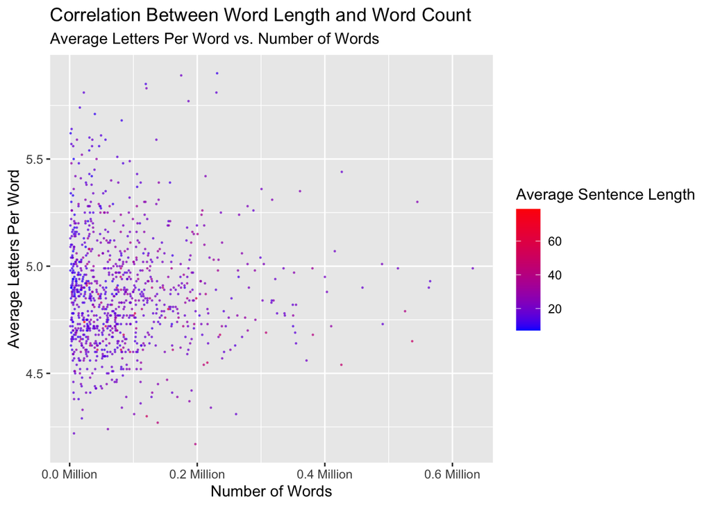

```r
stats_subset |>
  filter(
    stats.words >= median(stats_subset$stats.words) - 3 * sd(stats_subset$stats.words),
    stats.words <= median(stats_subset$stats.words) + 3 * sd(stats_subset$stats.words),
    stats.avg_letter_per_word >= median(stats_subset$stats.avg_letter_per_word) - 3 * sd(stats_subset$stats.avg_letter_per_word),
    stats.avg_letter_per_word <= median(stats_subset$stats.avg_letter_per_word) + 3 * sd(stats_subset$stats.avg_letter_per_word)
  ) |>
  ggplot(aes(x = stats.words, y = stats.avg_letter_per_word, color = stats.avg_sentence_length)) +
  geom_point(alpha = 0.6, size = .2) +
  labs(title = "Correlation Between Word Length and Word Count",
    subtitle = "Average Letters Per Word vs. Number of Words",
       x = "Number of Words",
       y = "Average Letters Per Word",
       color = "Average Sentence Length") +
  scale_color_gradient(low = "blue", high = "red", name = "Average Sentence Length") +
  scale_x_continuous(labels = scales::comma_format(scale = 1e-6, suffix = " Million"))
```

The same thing but with the y-axis and colors flipped

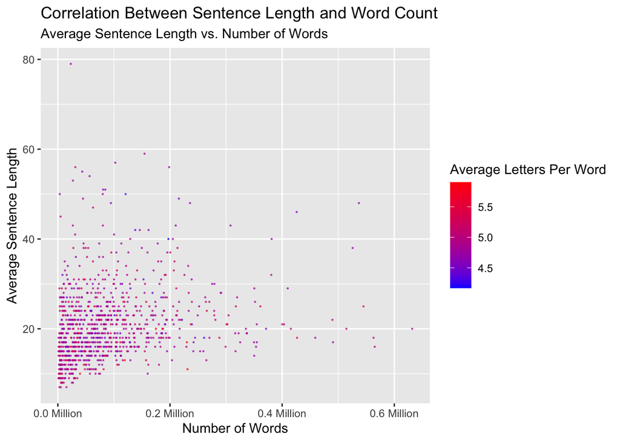

```r
stats_subset |>
  filter(
    stats.words >= median(stats_subset$stats.words) - 3 * sd(stats_subset$stats.words),
    stats.words <= median(stats_subset$stats.words) + 3 * sd(stats_subset$stats.words),
    stats.avg_letter_per_word >= median(stats_subset$stats.avg_letter_per_word) - 3 * sd(stats_subset$stats.avg_letter_per_word),
    stats.avg_letter_per_word <= median(stats_subset$stats.avg_letter_per_word) + 3 * sd(stats_subset$stats.avg_letter_per_word)
  ) |>
  ggplot(aes(x = stats.words, y = stats.avg_sentence_length , color = stats.avg_letter_per_word)) +
  geom_point(alpha = 0.6, size = .2) +
  labs(title = "Correlation Between Sentence Length and Word Count",
    subtitle = "Average Sentence Length vs. Number of Words",
       x = "Number of Words",
       y = "Average Sentence Length",
       color = "Average Letters Per Word") +
  scale_color_gradient(low = "blue", high = "red", name = "Average Letters Per Word") +
  scale_x_continuous(labels = scales::comma_format(scale = 1e-6, suffix = " Million"))
```

Lets identify those outliers

```r
word <- stats_subset |>
  filter(stats.avg_sentence_length > 75)
word$title
```

```
[1] "Discourse on the Method of Rightly Conducting One's Reason and of Seeking Truth in the Sciences"
[2] "Fifteen Thousand Useful Phrases: A Practical Handbook Of Pertinent Expressions, Striking Similes, Literary, Commercial, Conversational, And Oratorical Terms, For The Embellishment Of Speech And Literature, And The Improvement Of The Vocabulary Of Those Persons Who Read, Write, And Speak English…
```

```r
rm(word)
```

That darn book – the other one is [by Descartes](https://www.gutenberg.org/files/59/59-h/59-h.htm)

### Graph Character Count over Word Count

Graph `stats.characters` over `stats.words`

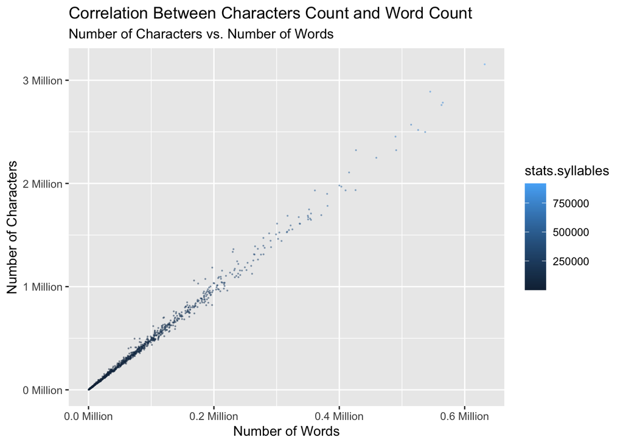

```r
stats_subset |>
  filter(
    stats.words >= median(stats_subset$stats.words) - 3 * sd(stats_subset$stats.words),
    stats.words <= median(stats_subset$stats.words) + 3 * sd(stats_subset$stats.words),
    stats.characters >= median(stats_subset$stats.characters) - 3 * sd(stats_subset$stats.characters),
    stats.characters <= median(stats_subset$stats.characters) + 3 * sd(stats_subset$stats.characters)
  ) |>
  ggplot(aes(x = stats.words, y = stats.characters, color = stats.syllables)) +
  geom_point(alpha = 0.4, size = .1) +
  labs(title = "Correlation Between Characters Count and Word Count",
    subtitle = "Number of Characters vs. Number of Words",
       x = "Number of Words",
       y = "Number of Characters") +
  scale_x_continuous(labels = scales::comma_format(scale = 1e-6, suffix = " Million")) +
  scale_y_continuous(labels = scales::comma_format(scale = 1e-6, suffix = " Million"))
```

Lets switch `stats.characters` and `stats.syllables`

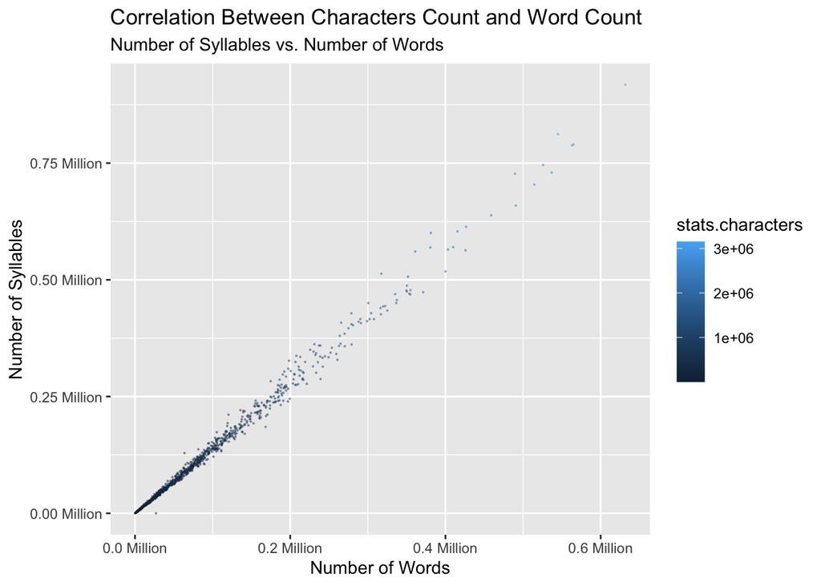

```r
stats_subset |>
  filter(
    stats.words >= median(stats_subset$stats.words) - 3 * sd(stats_subset$stats.words),
    stats.words <= median(stats_subset$stats.words) + 3 * sd(stats_subset$stats.words),
    stats.syllables >= median(stats_subset$stats.syllables) - 3 * sd(stats_subset$stats.syllables),
    stats.syllables <= median(stats_subset$stats.syllables) + 3 * sd(stats_subset$stats.syllables)
  ) |>
  ggplot(aes(x = stats.words, y = stats.syllables, color = stats.characters)) +
  geom_point(alpha = 0.4, size = .1) +
  labs(title = "Correlation Between Characters Count and Word Count",
    subtitle = "Number of Syllables vs. Number of Words",
       x = "Number of Words",
       y = "Number of Syllables") +
  scale_x_continuous(labels = scales::comma_format(scale = 1e-6, suffix = " Million")) +
  scale_y_continuous(labels = scales::comma_format(scale = 1e-6, suffix = " Million"))
```

But what about `stats.sentences`?

[figure not shown]

```r
stats_subset |>
  filter(
    stats.sentences >= median(stats_subset$stats.sentences) - 3 * sd(stats_subset$stats.sentences),
    stats.sentences <= median(stats_subset$stats.sentences) + 3 * sd(stats_subset$stats.sentences),
    stats.syllables >= median(stats_subset$stats.syllables) - 3 * sd(stats_subset$stats.syllables),
    stats.syllables <= median(stats_subset$stats.syllables) + 3 * sd(stats_subset$stats.syllables)
  ) |>
  ggplot(aes(x = stats.sentences, y = stats.syllables, color = stats.characters)) +
  geom_point(alpha = 0.4, size = .1) +
  labs(title = "Correlation Between Characters Count and Word Count",
    subtitle = "Number of Syllables vs. Number of Words",
       x = "Number of Sentences",
       y = "Number of Syllables") +
  scale_x_continuous(labels = scales::comma_format(scale = 1e-6, suffix = " Million")) +
  scale_y_continuous(labels = scales::comma_format(scale = 1e-6, suffix = " Million"))
```